# FPP - Ch. 8 Exercises

##### Dan Hong | dnaeye@gmail.com

The following are my answers to the exercises in the excellent book [Forecasting: Principles & Practice](https://otexts.org/fpp2/) by Rob J Hyndman and George Athanasopoulos.

#### 1. Figure [8.31](https://otexts.org/fpp2/arima-exercises.html#fig:wnacfplus) shows the ACFs for 36 random numbers, 360 random numbers and 1,000 random numbers.

**1a.** Explain the differences among these figures. Do they all indicate that the data are white noise?

Based on the ACF plots, the left two datasets have some significant autocorrelation (e.g., lag 12 in the 1st plot; lags 2 and 6 in the 2nd plot), but most are within the blue lines of significance.

**1b.** Why are the critical values at different distances from the mean of zero? Why are the autocorrelations different in each figure when they each refer to white noise?

Because white noise is random, autocorrelations are also random and can happen at different lags of varying degrees.

#### 2. A classic example of a non-stationary series is the daily closing IBM stock price series (data set `ibmclose`). Use R to plot the daily closing prices for IBM stock and the ACF and PACF. Explain how each plot shows that the series is non-stationary and should be differenced.

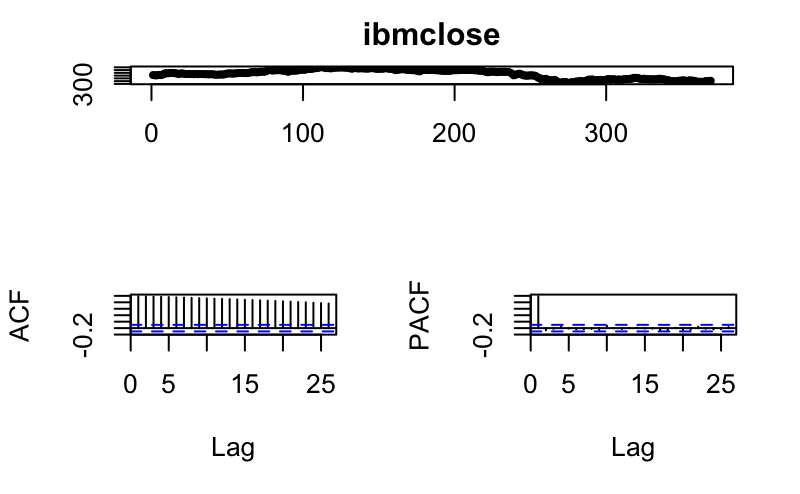

```r
tsdisplay(ibmclose)
```

The data points in the regular time-series plot appear to be a random walk, which implies that each point is highly correlated with the previous point.

The ACF plot shows significant and very large autocorrelation at every lag.

The PACF plot shows only significant autocorrelation at the 1st lag, which is expected, as it is actually itself (see [Ch. 8.5](https://otexts.org/fpp2/non-seasonal-arima.html)). This indicates that even first-order differencing will make the data stationary (i.e., white noise).

#### 3. For the following series, find an appropriate Box-Cox transformation and order of differencing in order to obtain stationary data.

**3a.** `usnetelec`

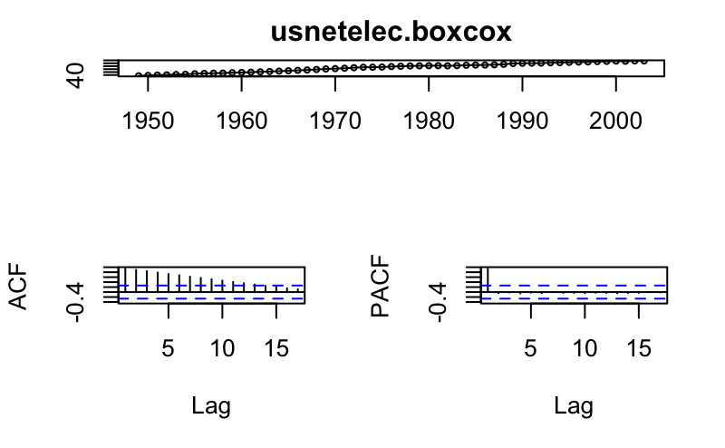

```r
usnetelec.lambda <- BoxCox.lambda(usnetelec)
usnetelec.boxcox <- BoxCox(usnetelec, lambda=usnetelec.lambda)
tsdisplay(usnetelec.boxcox)
```

```r
# nsdiffs(usnetelec.boxcox) : error due to non-seasonal data
ndiffs(usnetelec.boxcox)
```

```
[1] 2
```

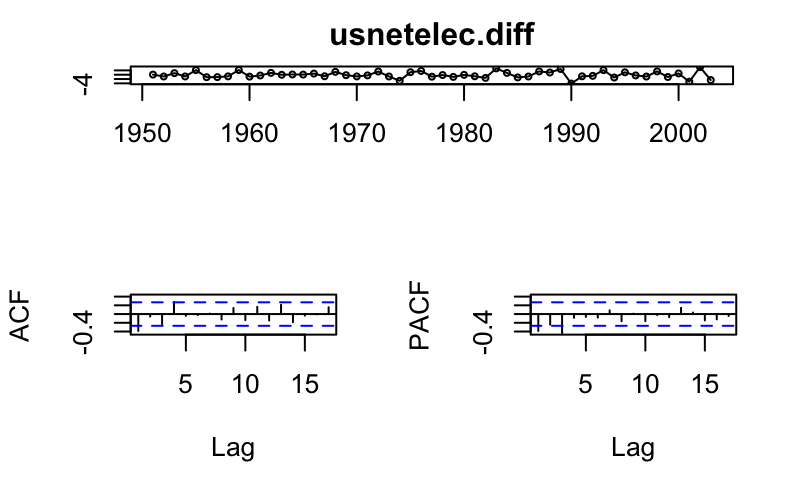

```r
#usnetelec.diff <- diff(diff(usnetelec.boxcox))
usnetelec.diff <- diff(usnetelec.boxcox, differences=2)
tsdisplay(usnetelec.diff)
```

Second-order differencing was required.

**3b.** `usgdp`

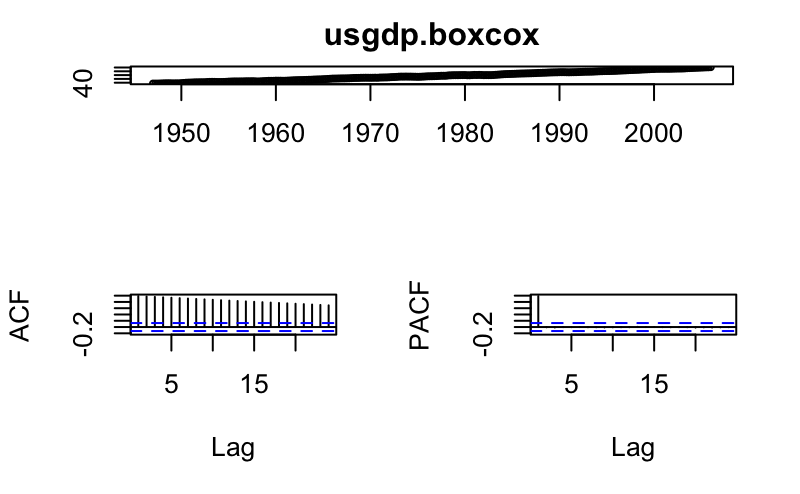

```r
usgdp.lambda <- BoxCox.lambda(usgdp)
usgdp.boxcox <- BoxCox(usgdp, lambda = usgdp.lambda)
tsdisplay(usgdp.boxcox)
```

```r
nsdiffs(usgdp.boxcox)
```

```
[1] 0
```

```r
ndiffs(usgdp.boxcox)
```

```
[1] 1
```

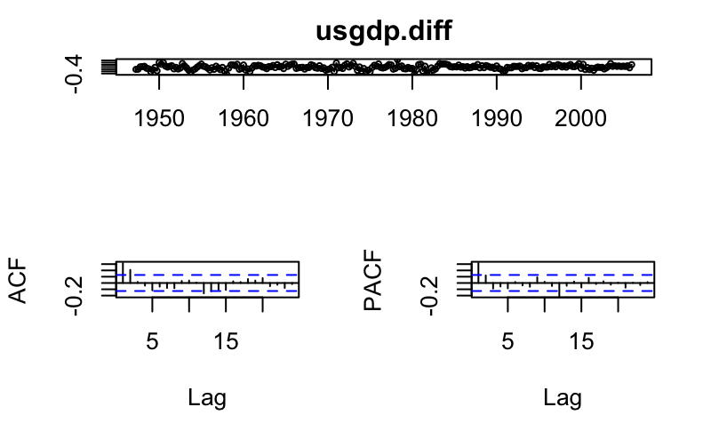

```r
usgdp.diff <- diff(usgdp.boxcox)
tsdisplay(usgdp.diff)
```

First-order differencing on the transformed data was sufficient.

**3c.** `mcopper`

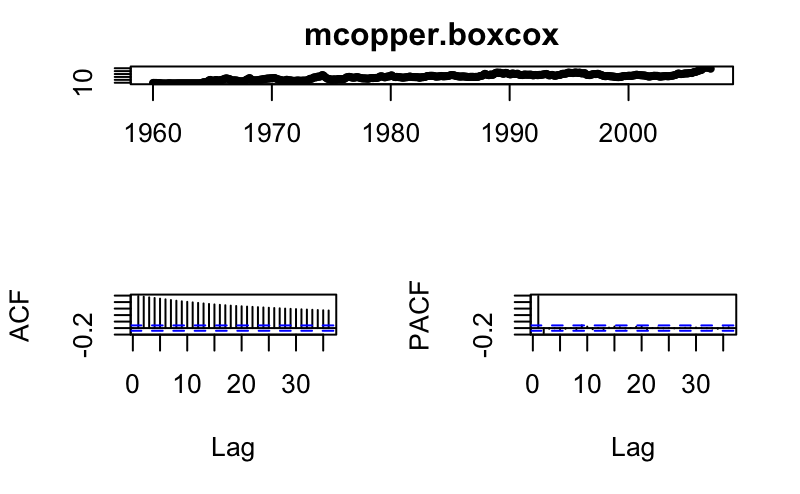

```r
mcopper.lambda = BoxCox.lambda(mcopper)
mcopper.boxcox = BoxCox(mcopper, lambda=mcopper.lambda)
tsdisplay(mcopper.boxcox)
```

```r
nsdiffs(mcopper.boxcox)
```

```
[1] 0
```

```r
ndiffs(mcopper.boxcox)
```

```
[1] 1
```

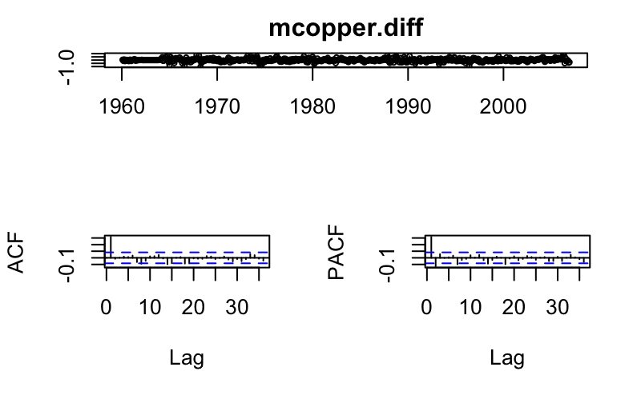

```r
mcopper.diff <- diff(mcopper.boxcox)
tsdisplay(mcopper.diff)
```

First-order differencing on the transformed data was sufficient.

**3d.** `enplanements`

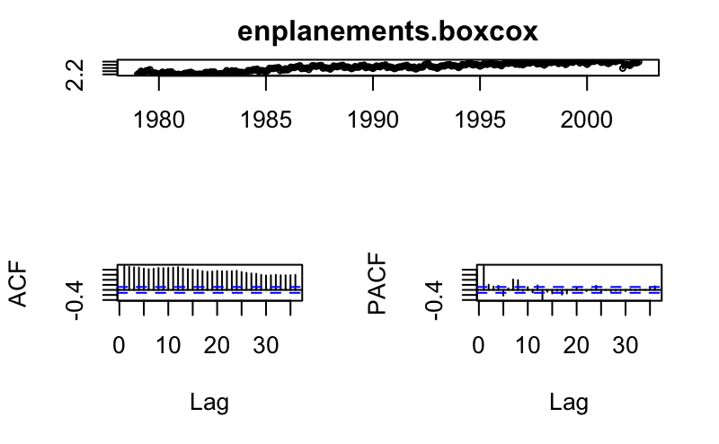

```r
enplanements.lambda = BoxCox.lambda(enplanements)
enplanements.boxcox = BoxCox(enplanements, lambda=enplanements.lambda)
tsdisplay(enplanements.boxcox)
```

```r
nsdiffs(enplanements.boxcox)
```

```
[1] 1
```

```r
ndiffs(enplanements.boxcox)
```

```
[1] 1
```

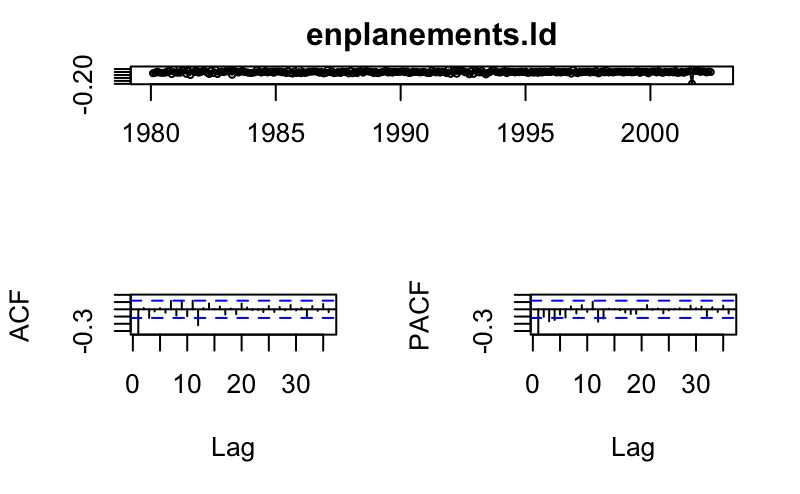

```r
enplanements.sd <- diff(enplanements.boxcox, 12)
enplanements.ld <- diff(enplanements.sd)
tsdisplay(enplanements.ld)
```

Both seasonal and first-order differencing were required.

**3e.** `visitors`

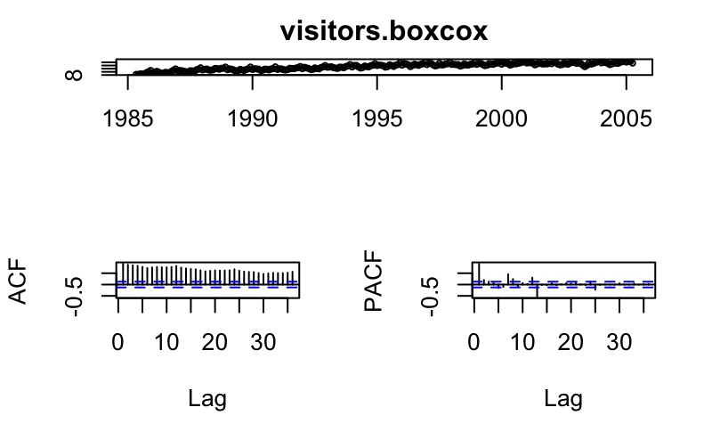

```r
visitors.lambda <- BoxCox.lambda(visitors)
visitors.boxcox <- BoxCox(visitors, lambda=visitors.lambda)
tsdisplay(visitors.boxcox)
```

```r
nsdiffs(visitors.boxcox)
```

```
[1] 1
```

```r
ndiffs(visitors.boxcox)
```

```
[1] 1
```

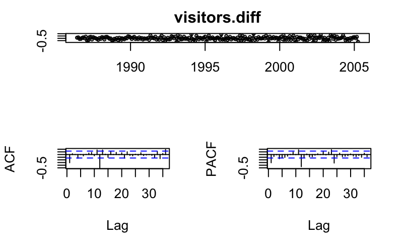

```r
visitors.sd <- diff(visitors.boxcox, 12)
visitors.diff <- diff(visitors.sd)
tsdisplay(visitors.diff)
```

Both seasonal and first-order differencing were required.

#### 4. For the `enplanements` data, write down the differences you chose above using backshift operator notation.

$(1-B)(1-B^m)y_t = 1(1-B-B^m+B^{m+1})y_t$ $=y_t-y_{t-1}-y_{t-m}+y_{t-m-1}$

#### 5. For your retail data (from Exercise 3 in Section [2.10](https://otexts.org/fpp2/graphics-exercises.html#graphics-exercises)), find the appropriate order of differencing (after transformation if necessary) to obtain stationary data.

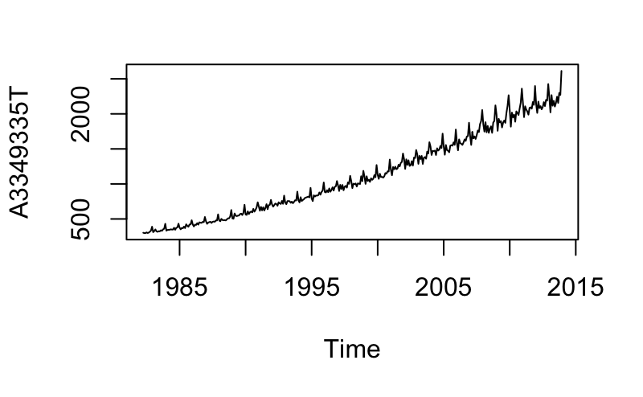

```r
plot(retail)
```

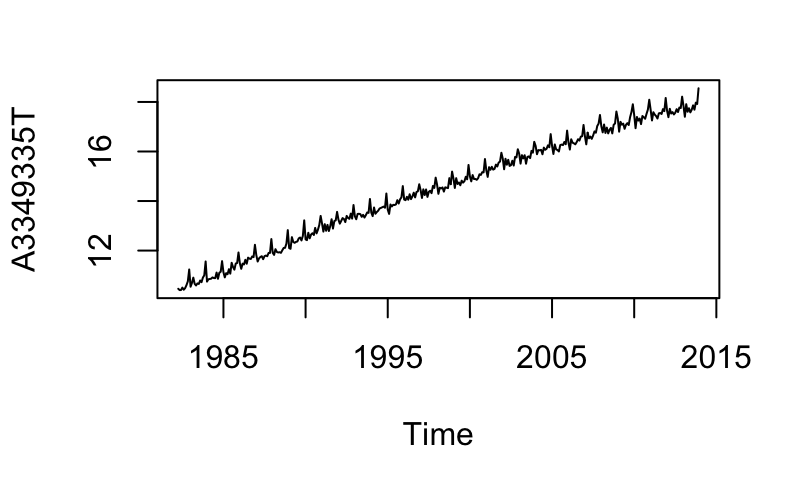

```r
retail.lambda <- BoxCox.lambda(retail)
retail.boxcox <- BoxCox(retail, lambda=retail.lambda)
plot(retail.boxcox)
```

```r
nsdiffs(retail.boxcox)
```

```
[1] 1
```

```r
ndiffs(retail.boxcox)
```

```
[1] 1
```

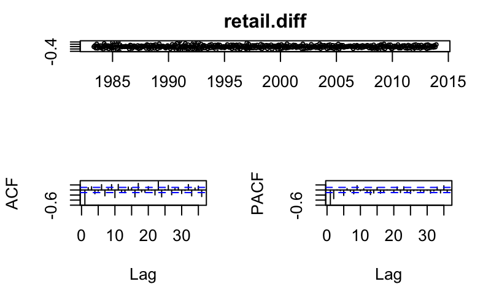

```r
retail.sd <- diff(retail.boxcox, 12)
retail.diff <- diff(retail.sd, 1)
tsdisplay(retail.diff)
```

My `retail` data required both seasonal and first-order differencing to make the data stationary.

#### 6. Use R to simulate and plot some data from simple ARIMA models.

**6a.** Use the following R code to generate data from an AR(1) model with $\phi_t = 0.6$ and $\sigma^2 = 1$. The process starts with $y_1 = 0.$

```r
y_0.6 <- ts(numeric(100))
e <- rnorm(100)
for(i in 2:100)
  y_0.6[i] <- 0.6*y_0.6[i-1] + e[i]
```

**6b.** Produce a time plot for the series. How does the plot change as you change $\phi_1$?

```r
y_1.0 <- ts(numeric(100))
for(i in 2:100)
  y_1.0[i] <- 1.0*y_1.0[i-1] + e[i]
y_0.2 <- ts(numeric(100))
for(i in 2:100)
  y_0.2[i] <- 0.2*y_0.2[i-1] + e[i]
```

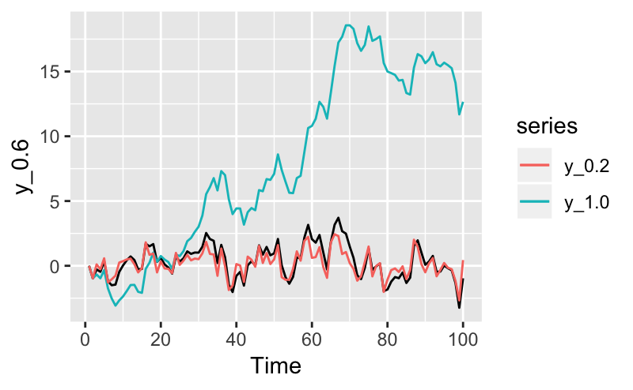

```r
autoplot(y_0.6) + autolayer(y_1.0) + autolayer(y_0.2)
```

As $\phi$ becomes smaller, the peaks and troughs in the plot generally become less extreme. On the other hand, as it gets larger, the more extreme they get.

**6c.** Write your own code to generate data from an MA(1) model with $\phi_1 = 0.6$ and $\sigma^2$ = 1.

```r
set.seed(123)
y <- ts(numeric(100))
e <- rnorm(100, mean=0, sd=1)
for(i in 2:100) {
  y[i] <- 3 + e[i] + 0.6*e[i-1]
}
```

**6d.** Produce a time plot for the series. How does the plot change as you change $\theta_1$?

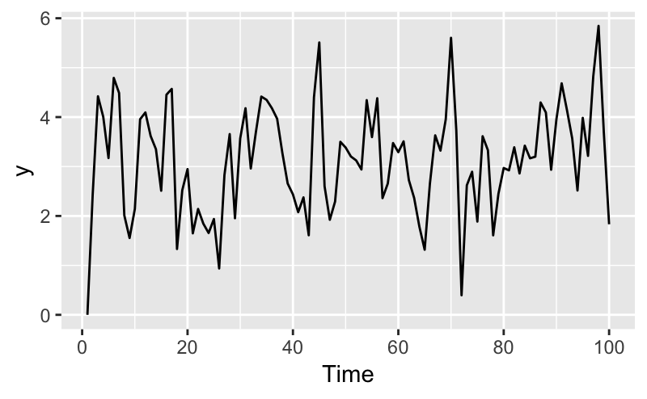

```r
autoplot(y)
```

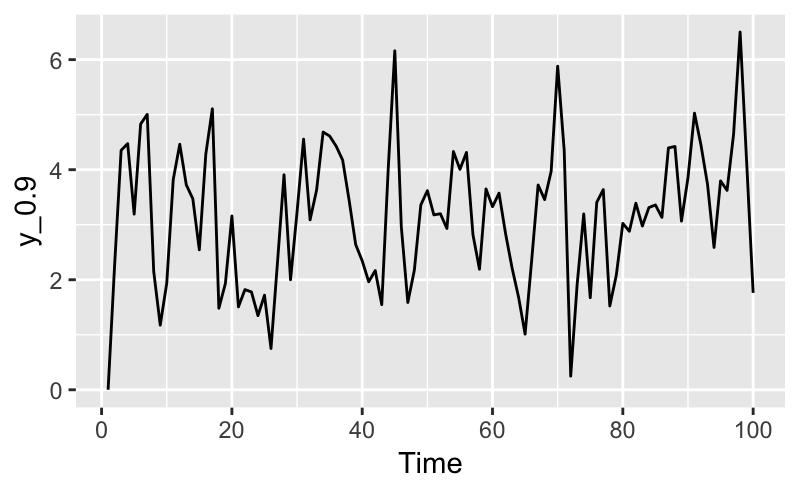

```r
set.seed(123)
y_0.9 <- ts(numeric(100))
e <- rnorm(100, mean=0, sd=1)
for(i in 2:100) {
  y_0.9[i] <- 3 + e[i] + 0.9*e[i-1]
}
autoplot(y_0.9)
```

With a larger $\theta$ - 0.9 - the pattern appears roughly the same, but the shape of some of the peaks and troughs are different. A few short peaks/troughs became more gradual, while others became more sharp.

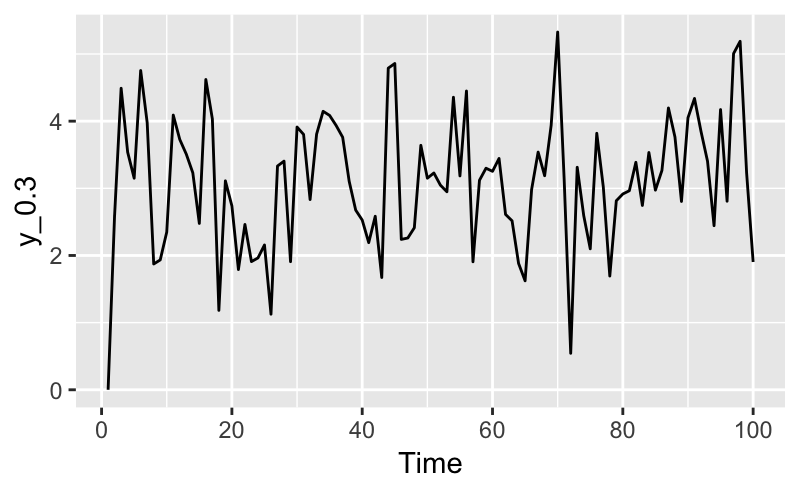

```r
set.seed(123)
y_0.3 <- ts(numeric(100))
e <- rnorm(100, mean=0, sd=1)
for(i in 2:100) {
  y_0.3[i] <- 3 + e[i] + 0.3*e[i-1]
}
autoplot(y_0.3)
```

Lowering $\theta$ to 0.3 appeared to have done the same.

**6e.** Generate data from an ARMA(1,1) model with $\phi_1$ = 0.6, $\theta_1$ = 0.6, and $\sigma^2$ = 1.

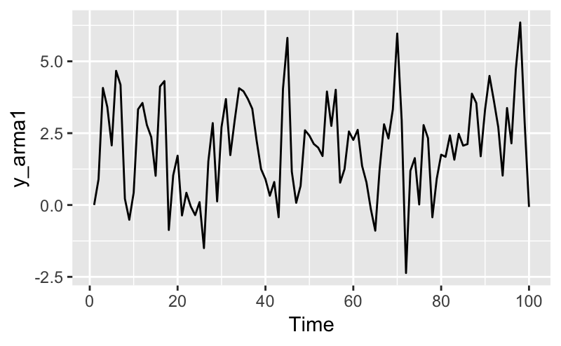

```r
set.seed(123)
y_arma1 <- ts(numeric(100))
e <- rnorm(100, mean=0, sd=1)
for(i in 2:100) {
  y_arma1[i] <- 0.6*y[i] + e[i] + 0.6*e[i-1]
}
autoplot(y_arma1)
```

The pattern has stayed roughly the same, but now some of the data points are negative.

**6f.** Generate data from an AR(2) model with $\phi_1$ = -0.8, $\phi_2$ = 0.3, and $\sigma^2$ = 1. (Note that these parameters will give a non-stationary series.)

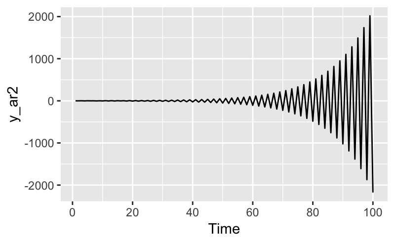

```r
set.seed(123)
y_ar2 <- ts(numeric(100))
e <- rnorm(100, mean=0, sd=1)
for(i in 3:100){
  y_ar2[i] <- -0.8*y_ar2[i-1] + 0.3*y_ar2[i-2] + e[i]
}
autoplot(y_ar2)
```

This AR(2) model interestingly has a very distinct pattern, regularly oscillating between positive and negative regions with increasing variance.

**6g.** Graph the latter two series and compare them.

As shown above, the ARMA(1) plot has a random, stationary pattern, while the AR(2) model exhibits a clear, non-stationary one.

#### 7. Consider `wmurders`, the number of women murdered each year (per 100,000 standard population) in the United States.

**7a.** By studying appropriate graphs of the series in R, find an appropriate ARIMA($p, d, q$) model for these data.

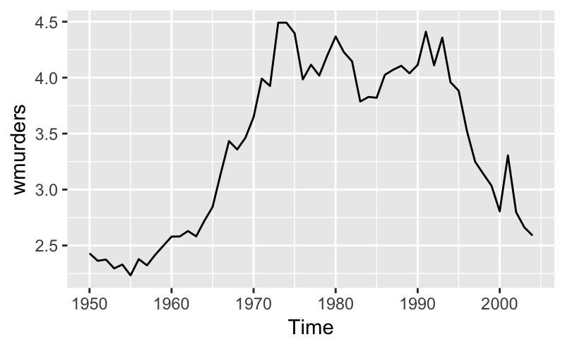

```r
autoplot(wmurders)
```

The time series does not appear to be stationary, so it needs to be differenced to make it so.

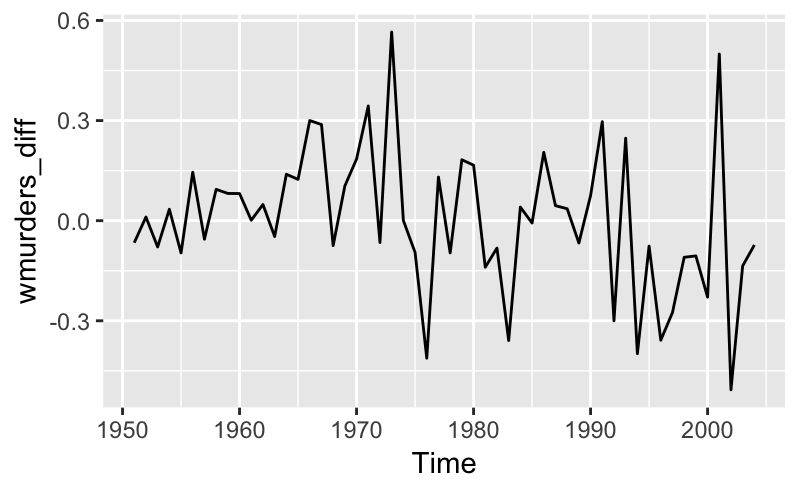

```r
wmurders_diff <- diff(wmurders)
autoplot(wmurders_diff)
```

There seems to be a negative trend in the differenced time series, so it’ll need to be differenced again.

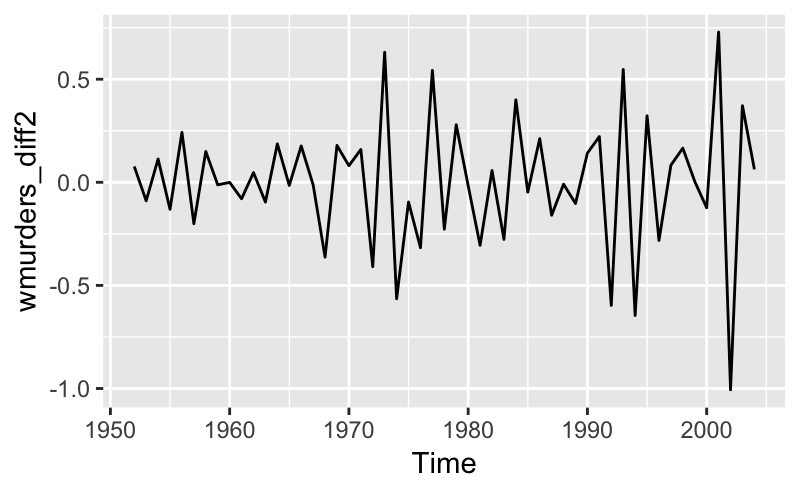

```r
wmurders_diff2 <- diff(wmurders, differences=2)
autoplot(wmurders_diff2)
```

The second-order differenced time series now appears stationary enough for further analysis.

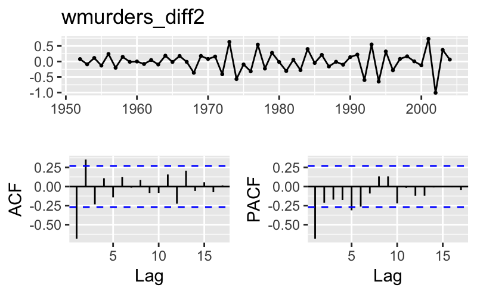

```r
ggtsdisplay(wmurders_diff2)
```

Although the lags in the ACF oscillate between negative and positive regions, the magnitude of these lags appear to be gradually getting smaller after lag 2, which would indicate a AR(1) model (since we should ignore lag 1 in an ACF plot).

So, the best model would be an ARIMA(1,2,1) model.

```r
Arima(wmurders, order=c(1,2,1))
```

```
Series: wmurders
ARIMA(1,2,1)

Coefficients:
          ar1      ma1
      -0.2434  -0.8261
s.e.   0.1553   0.1143

sigma^2 estimated as 0.04632:  log likelihood=6.44
AIC=-6.88   AICc=-6.39   BIC=-0.97
```

**7b.** Should you include a constant in the model? Explain.

No, because when $d$ > 1, including a constant would introduce a quadratic or higher order trend that is dangerous when forecasting. See the section on `Arima()` in Rob Hyndman’s [Hyndsight Blog](https://robjhyndman.com/hyndsight/arimaconstants/).

**7c.** Write this model in terms of the backshift operator.

$(1-\phi_1B)(1-B)^2y_t = (1+\theta_1B)\epsilon_t$

See [Ch. 8.2](https://otexts.org/fpp2/backshift.html) for backshift notation and [Ch. 8.5](https://otexts.org/fpp2/non-seasonal-arima.html) for non-seasonal ARIMA models.

**7d.** Fit the model using R and examine the residuals. Is the model satisfactory?

```
    Ljung-Box test

data:  Residuals from ARIMA(1,2,1)
Q* = 12.419, df = 8, p-value = 0.1335

Model df: 2.   Total lags used: 10
```

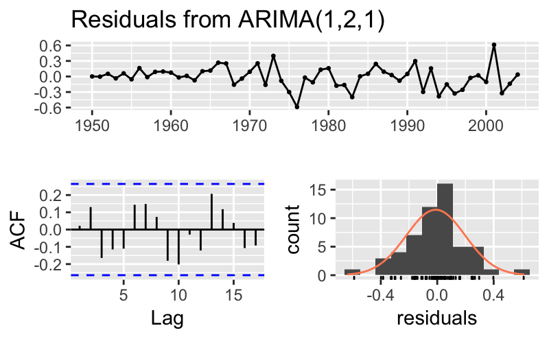

```r
fit <- Arima(wmurders, order=c(1,2,1))
checkresiduals(fit)
```

The ACF shows no significant lags among the residuals, which appear to be mostly normally distributed. Furthermore, the Ljung-Box test returned a large (i.e., greater than 0.05) p-value of 0.1335, so the time series is likely white noise.

**7e.** Forecast three times ahead. Check your forecasts by hand to make sure that you know how they have been calculated.

```r
fcast <- forecast(fit, h=3)
```

Not sure how to calculate the forecasts by hand.

**7f.** Create a plot of the series with forecasts and prediction intervals for the next three periods shown.

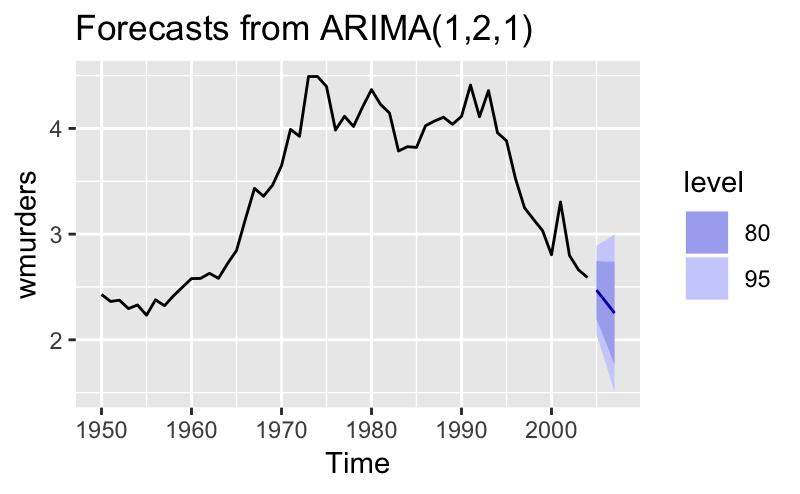

```r
autoplot(fcast)
```

**7g.** Does `auto.arima()` give the same model you have chosen? If not, which model do you think is better?

```r
fit_auto <- auto.arima(wmurders)
fit_auto
```

```
Series: wmurders
ARIMA(1,2,1)

Coefficients:
          ar1      ma1
      -0.2434  -0.8261
s.e.   0.1553   0.1143

sigma^2 estimated as 0.04632:  log likelihood=6.44
AIC=-6.88   AICc=-6.39   BIC=-0.97
```

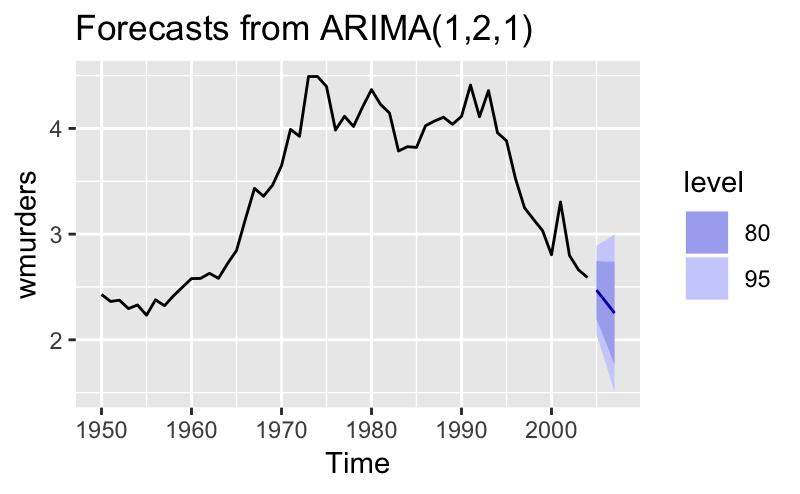

```r
autoplot(forecast(fit_auto, h=3))
```

Yes, `auto.arima` produced the same model.

#### 8. Consider `austa`, the total international visitors to Australia (in millions) for the period 1980-2015.

**8a.** Use `auto.arima()` to find an appropriate ARIMA model. What model was selected. Check that the residuals look like white noise. Plot forecasts for the next 10 periods.

```r
fit <- auto.arima(austa)
fit
```

```
Series: austa
ARIMA(0,1,1) with drift

Coefficients:
         ma1   drift
      0.3006  0.1735
s.e.  0.1647  0.0390

sigma^2 estimated as 0.03376:  log likelihood=10.62
AIC=-15.24   AICc=-14.46   BIC=-10.57
```

An ARIMA(0,1,1) with drift model was selected.

```
    Ljung-Box test

data:  Residuals from ARIMA(0,1,1) with drift
Q* = 2.297, df = 5.2, p-value = 0.8266

Model df: 2.   Total lags used: 7.2
```

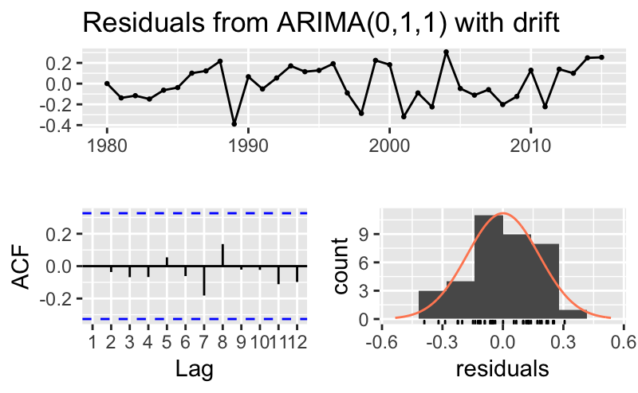

```r
checkresiduals(fit)
```

The ACF plot shows no significant lags, and the Ljung-Box test returned a non-significant p-value of 0.8266, indicating that the time series is likely white noise.

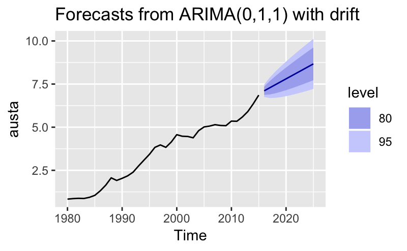

```r
autoplot(forecast(fit, h=10))
```

**8b.** Plot forecasts from an ARIMA(0,1,1) model with no drift and compare these to part a. Remove the MA term and plot again.

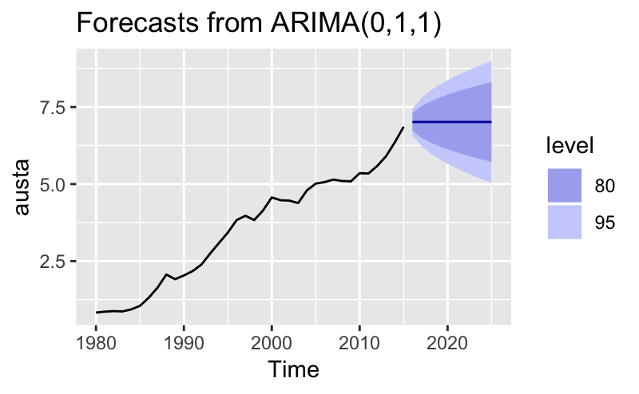

```r
Arima(austa, order=c(0,1,1), include.drift=FALSE) %>% forecast(h=10) %>% autoplot()
```

Compared to the plot in Part A, the forecasts are now just naively the last observation instead of making any attempt at forecasting a trend.

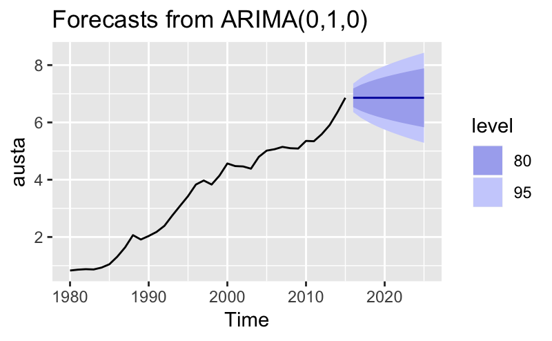

```r
Arima(austa, order=c(0,1,0), include.drift=FALSE) %>% forecast(h=10) %>% autoplot()
```